# Puppy Survey - Insurance Ban Breeds Analysis

Tom Kremer

Last Updated: 2026-01-05

### Preprocessing Notes

1. This page continues the series of typology analysis comparing one group to all the rest, this time with the Breed-based Homeowners Insurance Ban group. Below are the results for all survey questions after applying the renaming of breeds based on the provided lists, ending with a total of 1227 puppies in the Insurance Ban group compared to 2775 others.

## Introductory Questions (All Respondents)

## S5

**S5: What is your age, in years?**

4002 non-empty/NA responses out of 4002 possible responses ( 100 %)

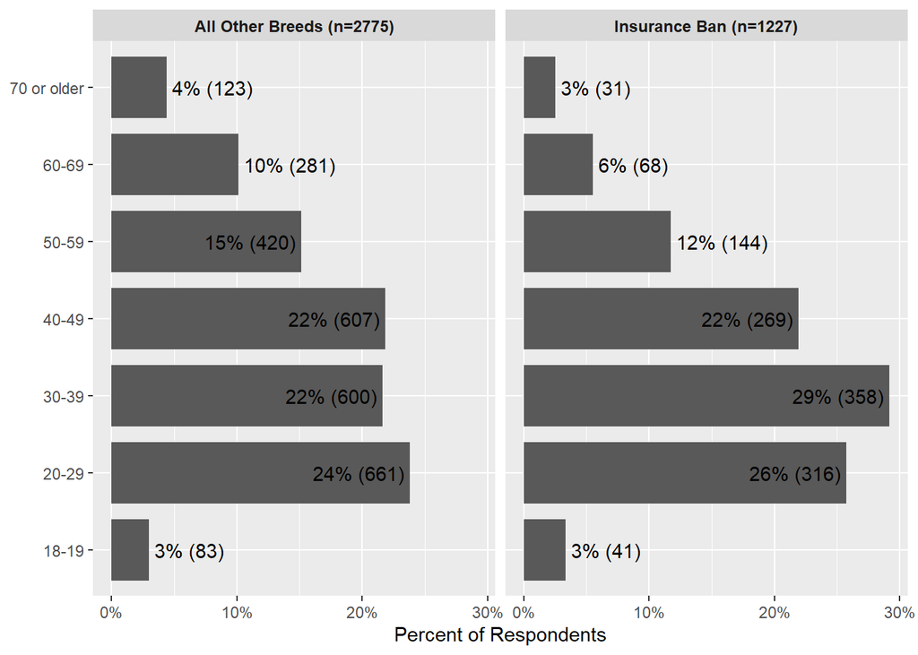

## Q1

**Q1: How old is your puppy now?**

4002 non-empty/NA responses out of 4002 possible responses ( 100 %)

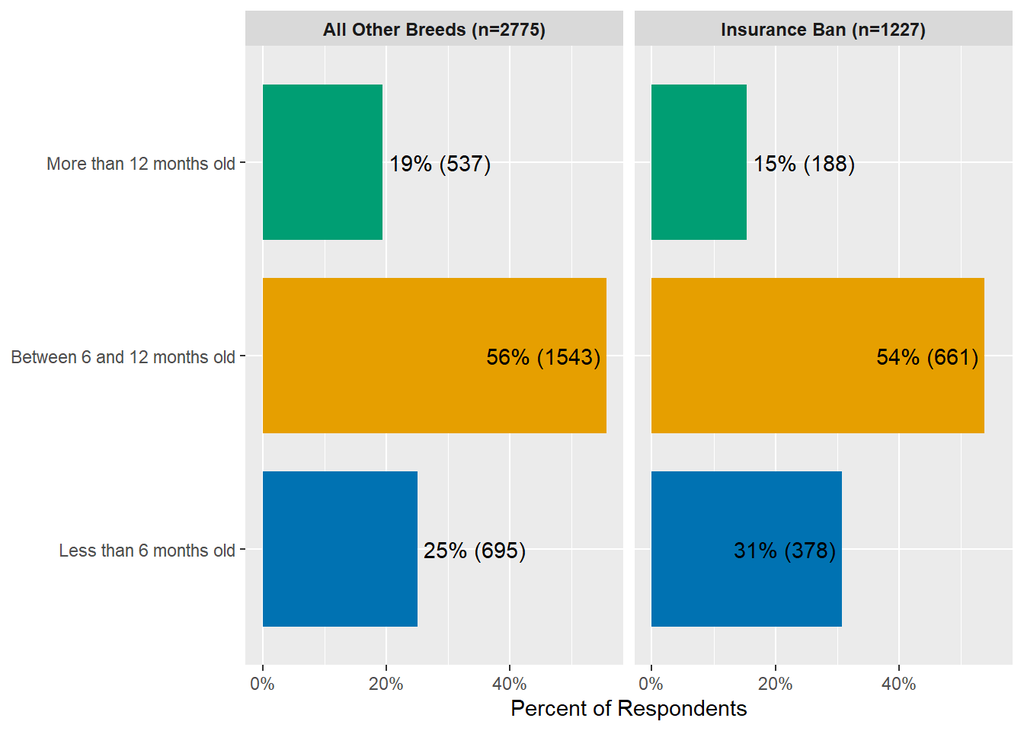

## Q2

**Q2: Are you the puppy’s first owner (besides the breeder, shop, rescue, or shelter where you got your puppy, if applicable)?**

4002 non-empty/NA responses out of 4002 possible responses ( 100 %)

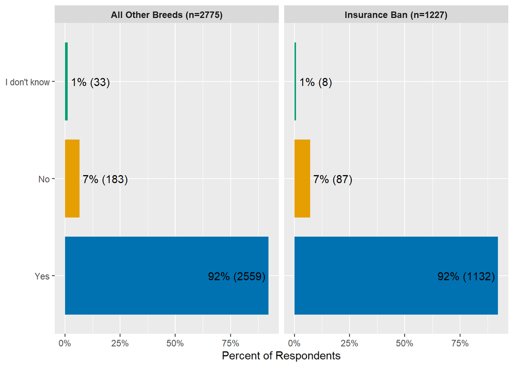

## Q3

**Q3: What is your puppy’s expected size when fully grown?**

4002 non-empty/NA responses out of 4002 possible responses ( 100 %)

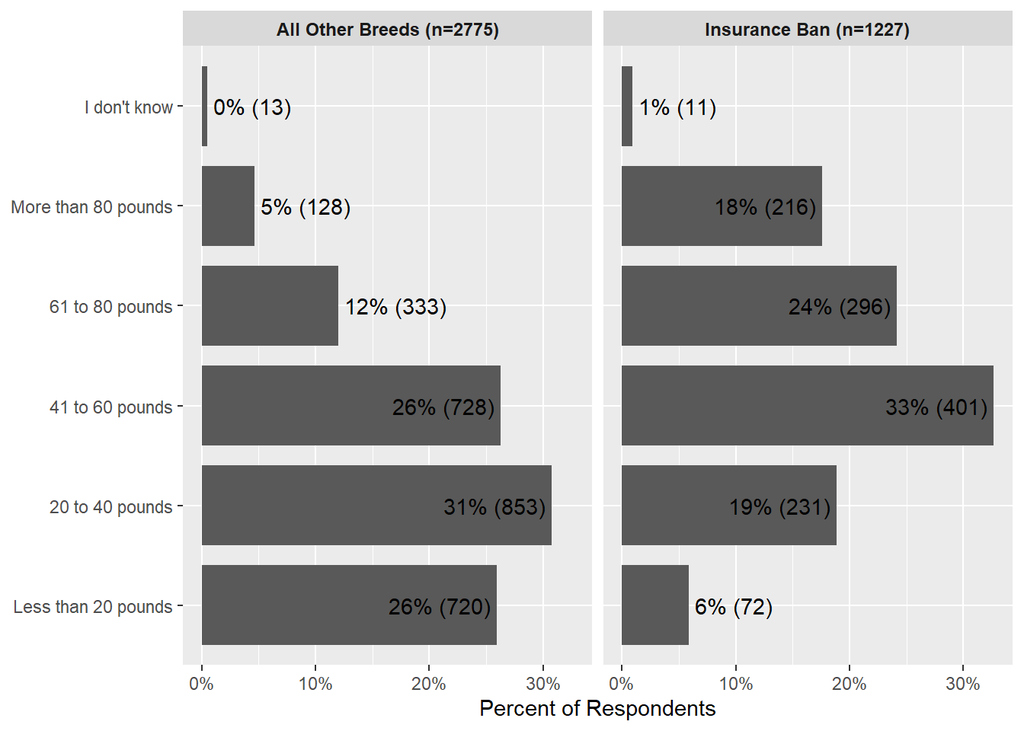

## Q5

**What information do you have on your puppy’s breed?**

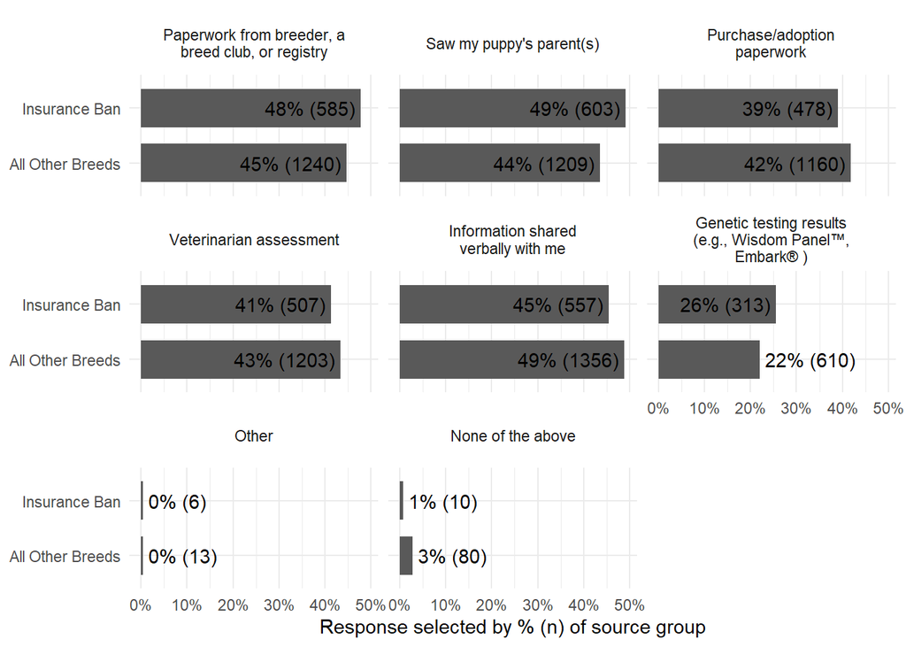

## Q4NEW_new (…)

**Q4: What best describes your puppy’s breed(s)?**

4002 non-empty/NA responses out of 4002 possible responses ( 100 %)

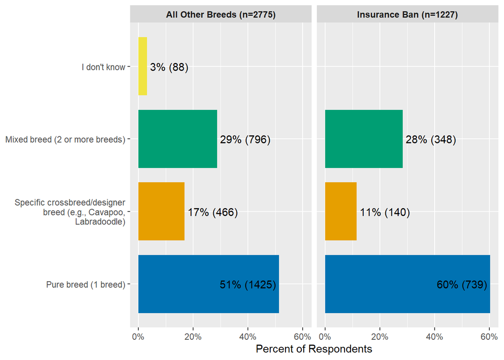

### > Q7

**Breed If answered pure breed**

Showing data for Typology breeds only

| Response | Count | Percent |
| --- | --- | --- |
| American Pit Bull Terrier | 233 | 32% |
| German Shepherd Dog | 161 | 22% |
| Siberian Husky | 70 | 9% |
| American Bulldog | 62 | 8% |
| Rottweiler | 53 | 7% |
| American Bully | 34 | 5% |
| Cane Corso | 34 | 5% |
| Doberman Pinscher | 24 | 3% |
| American Staffordshire Terrier | 17 | 2% |
| Dogue De Bordeaux (French Mastiff) | 17 | 2% |
| Akita | 7 | 1% |
| Bullmastiff | 6 | 1% |
| Chow Chow | 5 | 1% |
| Alaskan Malamute | 4 | 1% |
| Staffordshire Bull Terrier | 4 | 1% |
| English Mastiff | 4 | 1% |
| Neapolitan Mastiff | 2 | 0% |
| Xl Bully | 1 | 0% |
| German Rottweiler | 1 | 0% |

### > Q8

**Breed if answered specific crossbreed/designer**

Showing data for Typology breeds only

| Response | Count | Percent |
| --- | --- | --- |
| American Boston Bull Terrier (American Pitbull Terrier / Boston Terrier) | 28 | 20% |
| American Bullador (American Bulldog / Labrador) | 22 | 16% |
| Gerberian Shepsky (German Shepherd / Siberian Husky) | 20 | 14% |
| Goberian (Golden Retriever / Siberian Husky) | 18 | 13% |
| Pomsky (Pomeranian / Siberian Husky) | 9 | 6% |
| Golden Shepherd (Golden Retriever / German Shepherd) | 7 | 5% |
| German Sheprador (German Shepherd / Labrador) | 6 | 4% |
| American Bull Dogue De Bordeaux (American Bulldog / Dogue De Bordeaux) | 5 | 4% |
| Dutch Malinois (Dutch Shepherd / Belgian Malinois) | 5 | 4% |
| Catahoula Bulldog (Catahoula Leopard Dog / Bulldog) | 3 | 2% |
| Doberdor (Doberman Pincher / Labrador) | 3 | 2% |
| Labrabull (Labrador / American Pitbull Terrier) | 3 | 2% |
| Masti-Bull (Mastiff / American Bulldog) | 2 | 1% |
| Olde Pit Bulldogge (Olde English Bulldogge / American Pitbul | 2 | 1% |
| Mastador (Mastiff / Labrador) | 2 | 1% |
| Mastadane (Mastiff / Great Dane) | 2 | 1% |
| American Bullweiler (American Bulldog / Rottweiler) | 2 | 1% |
| English De Bordeaux (English Bulldog / Dogue De Bordeaux) | 1 | 1% |

### > Q9 (…)

**Breed if answered mixed breed**

Showing data for Typology breeds only

| Response | Count | Percent |
| --- | --- | --- |
| American Pit Bull Terrier | 90 | 26% |
| German Shepherd Dog | 62 | 18% |
| Pit Bull | 57 | 16% |
| Siberian Husky | 26 | 7% |
| American Bulldog | 22 | 6% |
| Rottweiler | 15 | 4% |
| Cane Corso | 13 | 4% |
| Doberman Pinscher | 11 | 3% |
| American Staffordshire Terrier | 10 | 3% |
| Bullmastiff | 9 | 3% |
| Alaskan Malamute | 7 | 2% |
| Husky | 7 | 2% |
| American Bully | 6 | 2% |
| Dogue de Bordeaux (French Mastiff) | 2 | 1% |
| Staffordshire Bull Terrier | 2 | 1% |
| American Pit Bull | 2 | 1% |
| Chow Chow | 1 | 0% |
| English Mastiff | 1 | 0% |
| Blue Nose Pit Bull | 1 | 0% |
| Stafford Terrier | 1 | 0% |
| Staffordshire | 1 | 0% |
| King Corso | 1 | 0% |
| Blue Pit | 1 | 0% |

#### >> Q10

**Q10: Would you like to add a second breed for your puppy?**

1144 non-empty/NA responses out of 1144 possible responses ( 100 %)

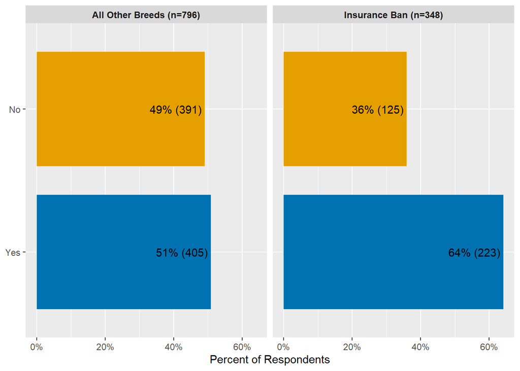

#### >> Q11

**Q11: Text - What is your puppy’s secondary breed? Please type the name in the text box below. It is okay if you are not certain of the breed; please provide your best guess. Select “I don’t know” only if you have no information on the breed.**

Showing data for Typology breeds only

| Response | Count | Percent |
| --- | --- | --- |
| Labrador Retriever | 35 | 16% |
| German Shepherd Dog | 19 | 9% |
| American Pit Bull Terrier | 16 | 7% |
| Boxer | 13 | 6% |
| Siberian Husky | 11 | 5% |
| American Bully | 9 | 4% |
|  | 7 | 3% |
| American Bulldog | 7 | 3% |
| Chihuahua | 6 | 3% |
| Pit Bull | 5 | 2% |
| Rottweiler | 5 | 2% |
| Beagle | 4 | 2% |
| American Staffordshire Terrier | 4 | 2% |
| Berger Picard | 4 | 2% |
| Golden Retriever | 4 | 2% |
| German Long Haired Pointer | 3 | 1% |
| Pomeranian | 3 | 1% |
| Bullmastiff | 3 | 1% |
| Great Dane | 3 | 1% |
| Rhodesian Ridgeback | 3 | 1% |
| Standard Dachshund | 2 | 1% |
| Irish Wolfhound | 2 | 1% |
| German Shorthaired Pointer | 2 | 1% |
| Catahoula Leopard Dog | 2 | 1% |
| Shih Tzu | 2 | 1% |
| Miniature Pinscher | 2 | 1% |
| Belgian Laekenois | 2 | 1% |
| Labrador Retriever and German Shepherd Dog | 2 | 1% |
| Australian Shepherd | 2 | 1% |
| German Pinscher | 2 | 1% |
| Coonhound | 2 | 1% |
| Tibetan Mastiff | 2 | 1% |
| Dalmatian | 2 | 1% |
| Dogue de Bordeaux (French Mastiff) | 1 | 0% |
| Bulldog | 1 | 0% |
| Yorkshire Terrier | 1 | 0% |
| Greyhound | 1 | 0% |
| Australian Cattle Dog (Blue Heeler) | 1 | 0% |
| Mountain Cur | 1 | 0% |
| Hou | 1 | 0% |
| Airedale Terrier | 1 | 0% |
| Red Heeler | 1 | 0% |
| Chow Chow | 1 | 0% |
| Afghan Hound | 1 | 0% |
| Alaskan Malamute | 1 | 0% |
| German Spitz | 1 | 0% |
| Rock Wiener | 1 | 0% |
| Shiba Inu | 1 | 0% |
| Great Pyrenees | 1 | 0% |
| Chesapeake Bay Retriever | 1 | 0% |
| Toy Poodle | 1 | 0% |
| Cane Corso | 1 | 0% |
| Pointer | 1 | 0% |
| Huntaway | 1 | 0% |
| Carolina Dog | 1 | 0% |
| Newfoundland | 1 | 0% |
| Staffordshire Bull Terrier | 1 | 0% |
| Belgian Malinois | 1 | 0% |
| Australian Silky Terrier | 1 | 0% |
| Husky | 1 | 0% |
| Bull Terrier | 1 | 0% |
| Belgian Sheepdog | 1 | 0% |
| Patterdale Terrier | 1 | 0% |
| Golden Doodle | 1 | 0% |
| Lacey | 1 | 0% |
| Doberman Pinscher | 1 | 0% |

## Q12 (…)

**Q12: Is your puppy sterilized (spayed or neutered)?**

4002 non-empty/NA responses out of 4002 possible responses ( 100 %)

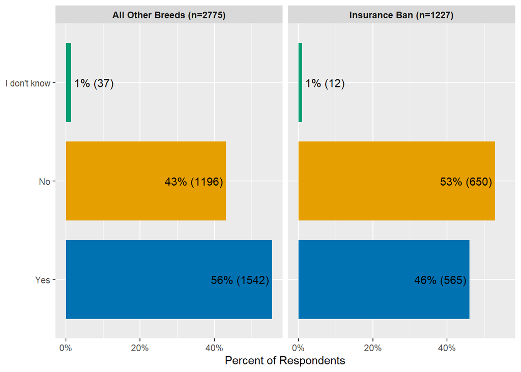

### > Q13 (…)

**Q13: Was your puppy sterilized before you brought them home?**

2107 non-empty/NA responses out of 2107 possible responses ( 100 %)

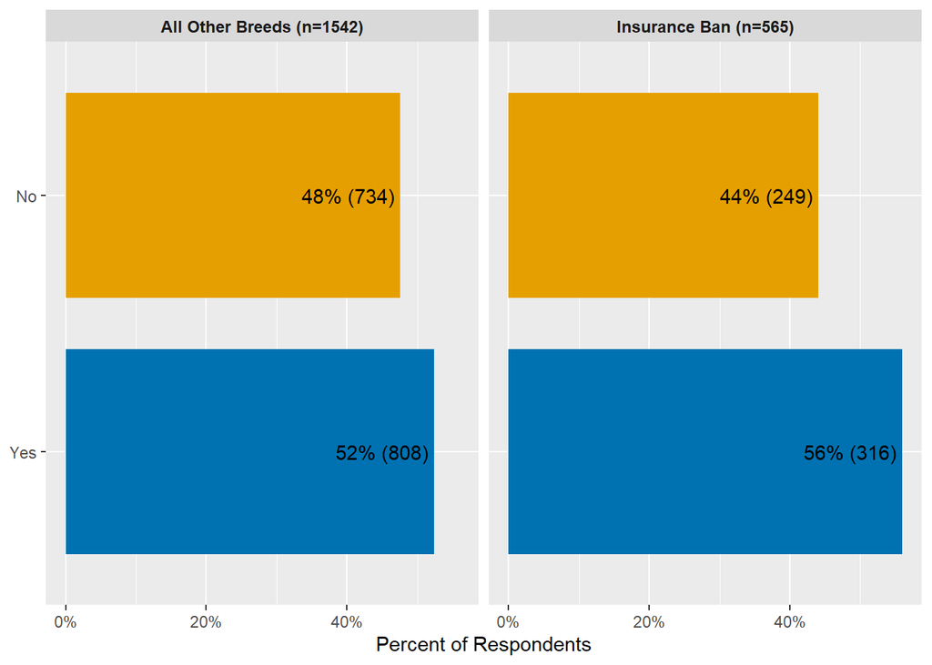

#### >> Q13a

**Q13a: At what age were they sterilized?**

983 non-empty/NA responses out of 983 possible responses ( 100 %)

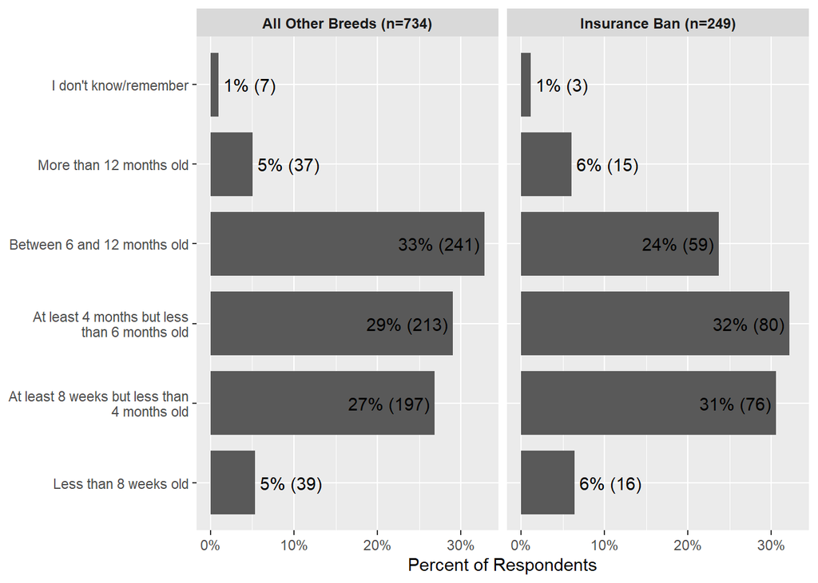

#### >> Q13b

**Q13b: Where did your puppy have their spay/neuter surgery?**

983 non-empty/NA responses out of 983 possible responses ( 100 %)

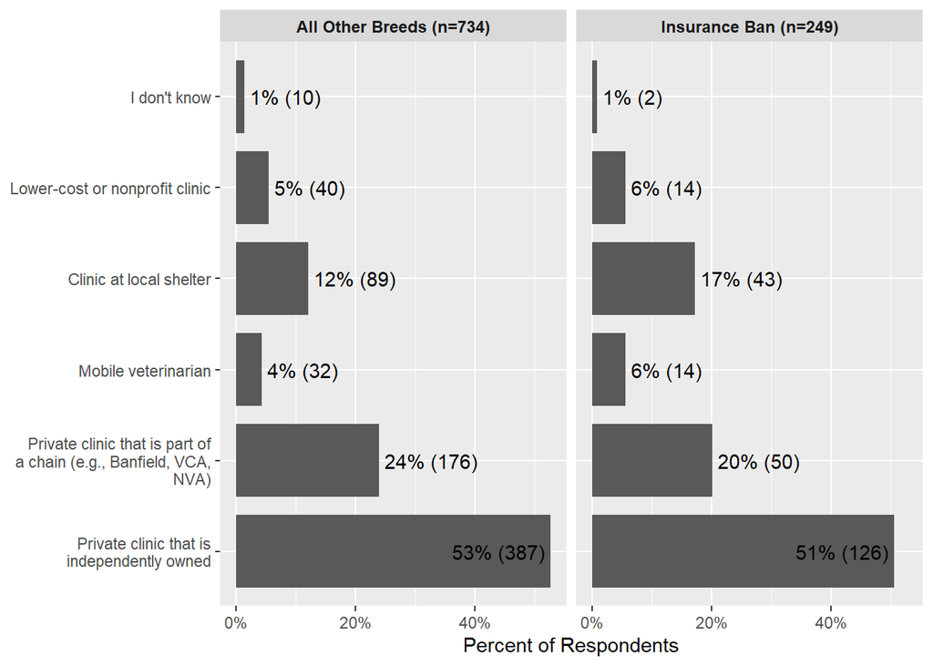

#### >> Q13c (…)

**Q13c: Has your puppy gone to a veterinarian since you got them other than for spay/neuter surgery?**

983 non-empty/NA responses out of 983 possible responses ( 100 %)

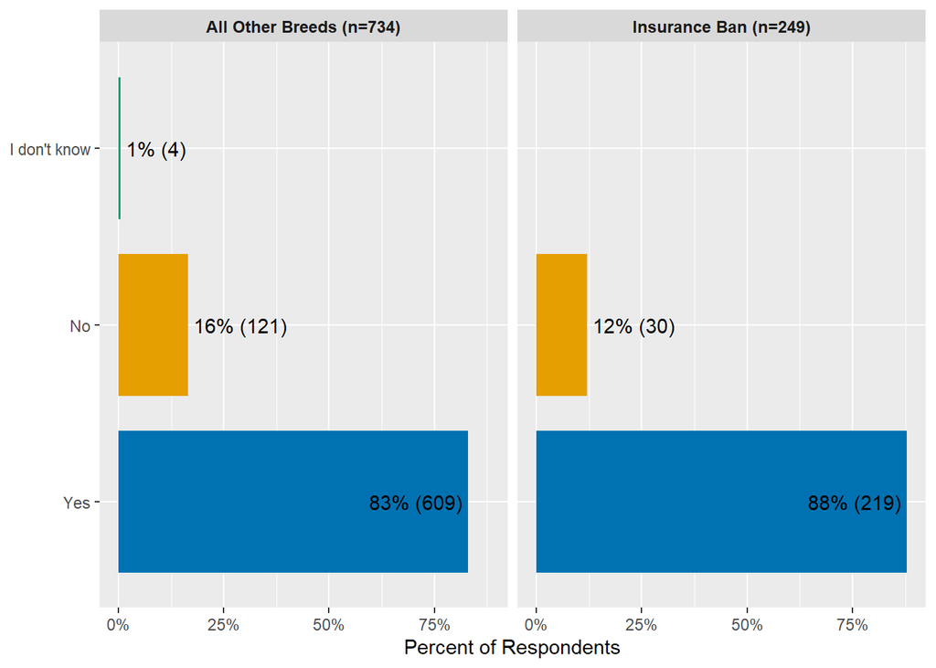

##### >>> Q13d

**Where has your puppy gone for other veterinary care?**

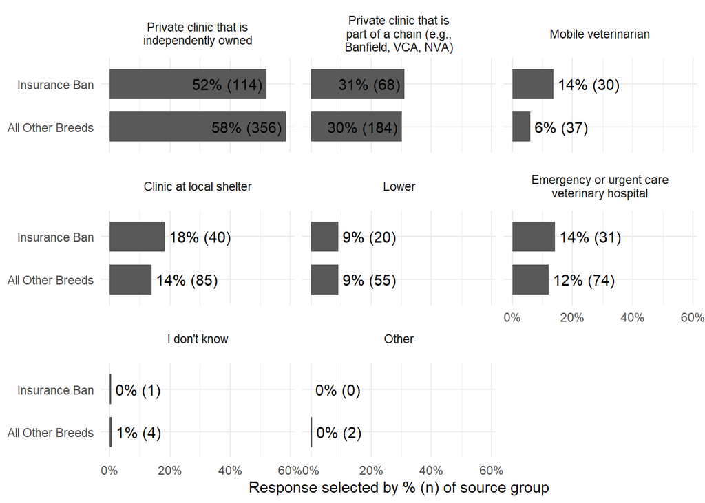

### > Q14

**Q14: Do you plan to breed your puppy in the future?**

1846 non-empty/NA responses out of 1895 possible responses ( 97 %)

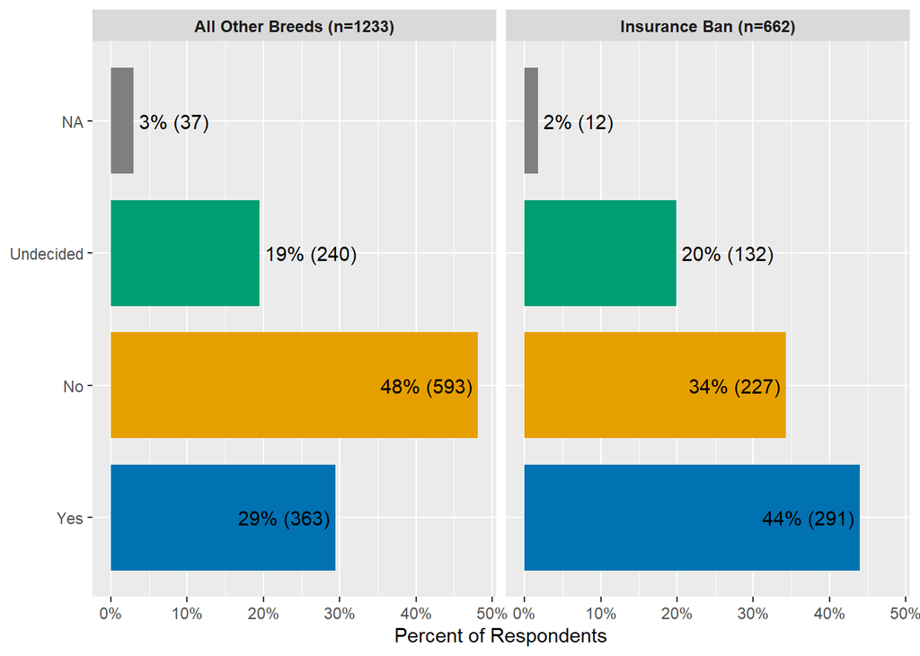

### > Q14a

**Q14a: Do you plan to sterilize your puppy in the future?**

1846 non-empty/NA responses out of 1895 possible responses ( 97 %)

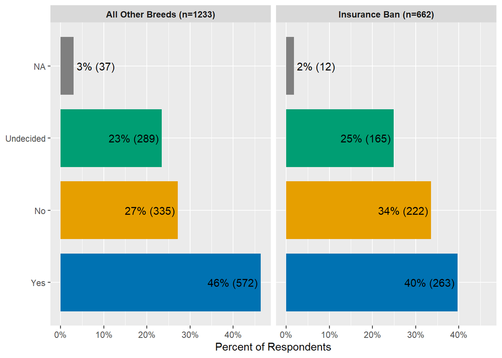

### > Q15

**Q15: Has your puppy gone to a veterinarian since you got them?**

3019 non-empty/NA responses out of 3019 possible responses ( 100 %)

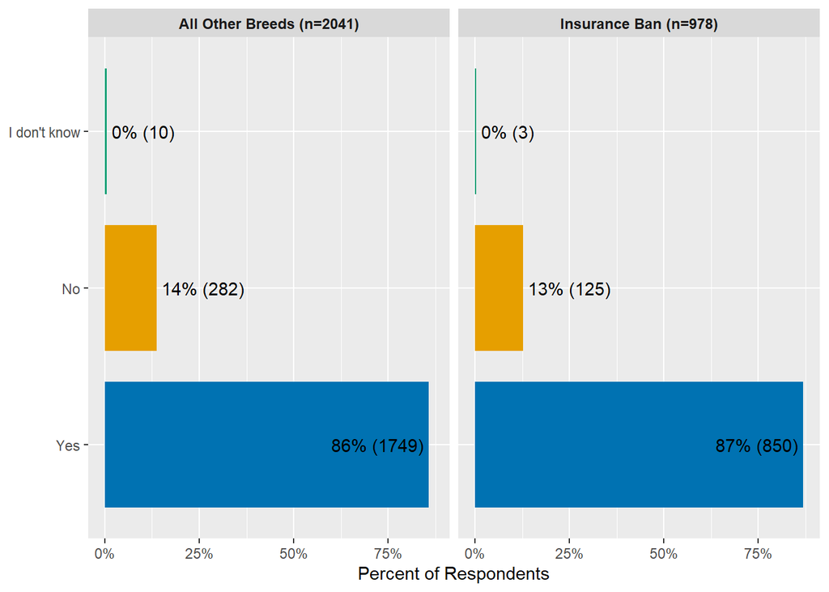

### > Q16

**Where has your puppy gone for veterinary care?**

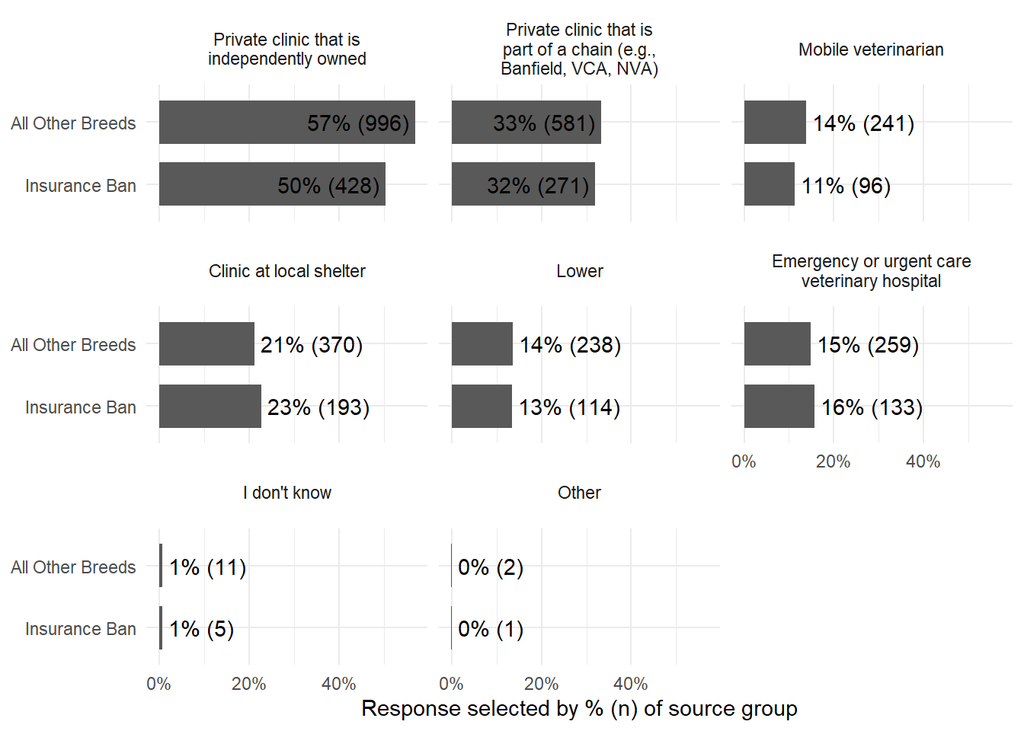

## Q17

**Q17: Before this puppy, were you ever a primary caretaker for a dog as an adult (when you were age 18 or older)?**

4002 non-empty/NA responses out of 4002 possible responses ( 100 %)

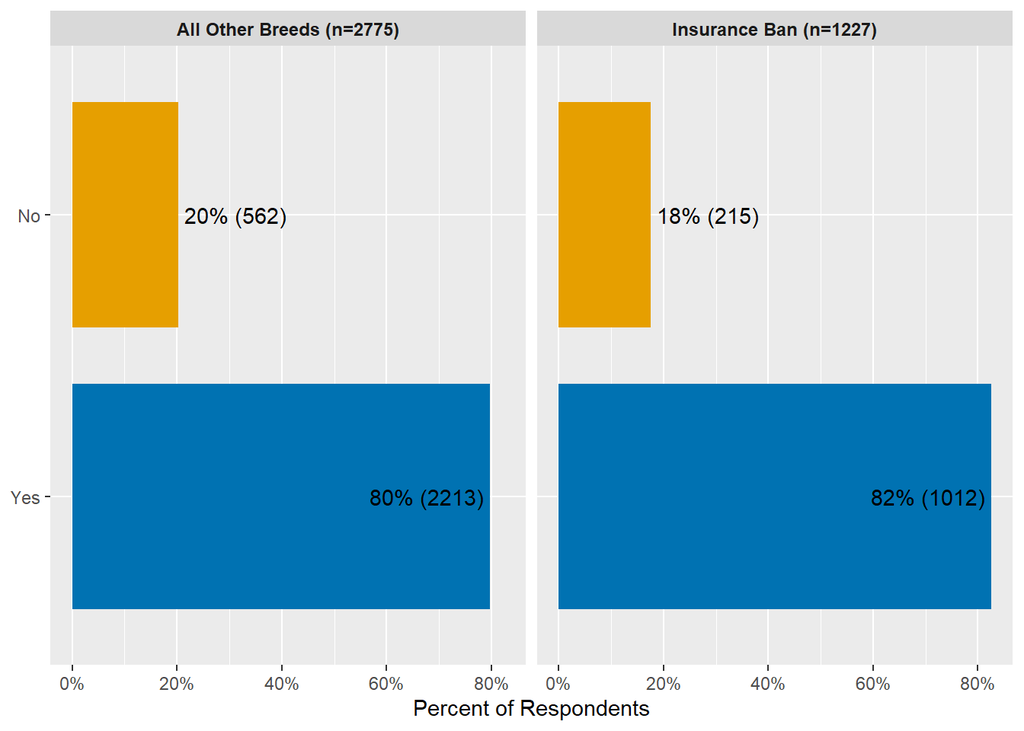

## Group A Only (…)

**Group A Only**

### > Timing and Availability

### > Q18 (…)

**Q18: How much time did you spend searching for a puppy?**

2001 non-empty/NA responses out of 2001 possible responses ( 100 %)

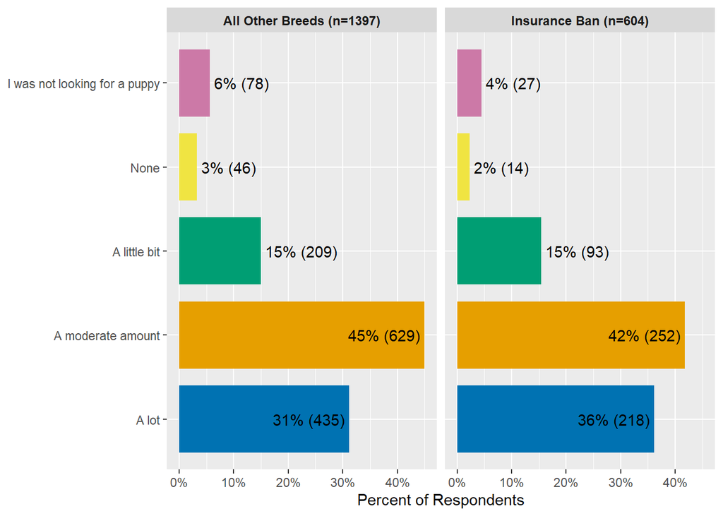

#### >> Q19

**You shared that you didn’t spend time searching for your puppy. Did any of the following apply to you getting your puppy?**

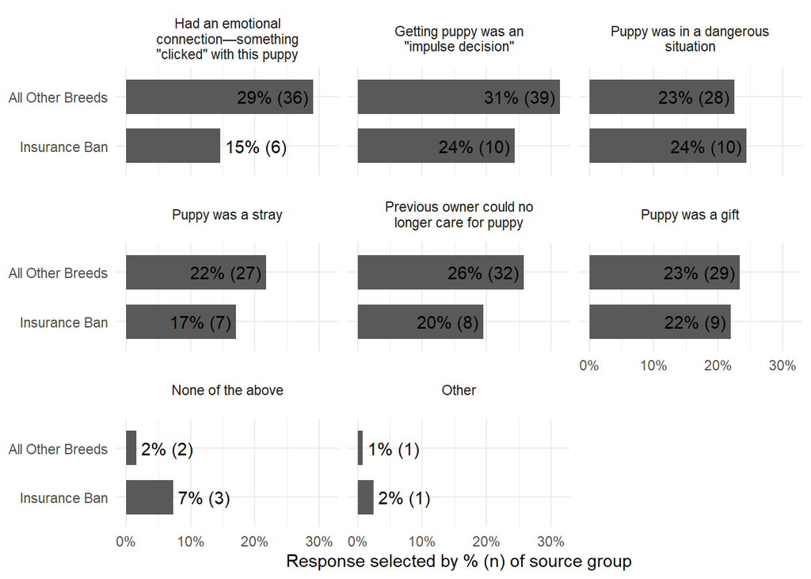

#### >> Q20

**Q20: How long was it from the time you started looking for a puppy to when you first brought your puppy home?**

1836 non-empty/NA responses out of 1836 possible responses ( 100 %)

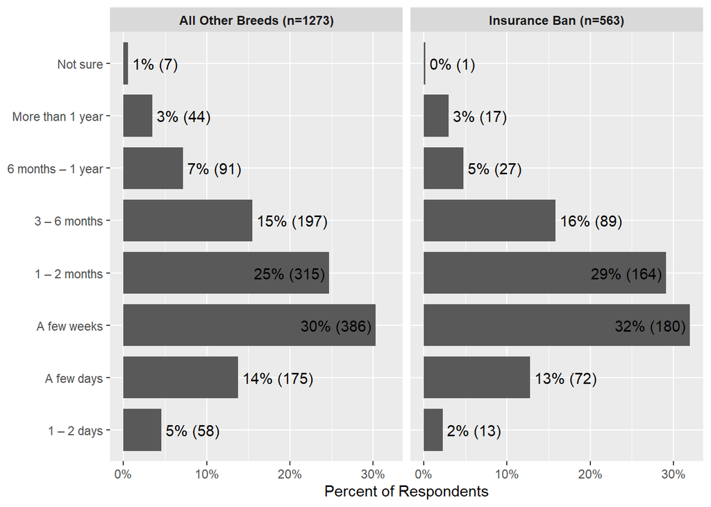

#### >> Q21 (…)

**Q21: How did this compare to the time you expected it would take?**

1836 non-empty/NA responses out of 1836 possible responses ( 100 %)

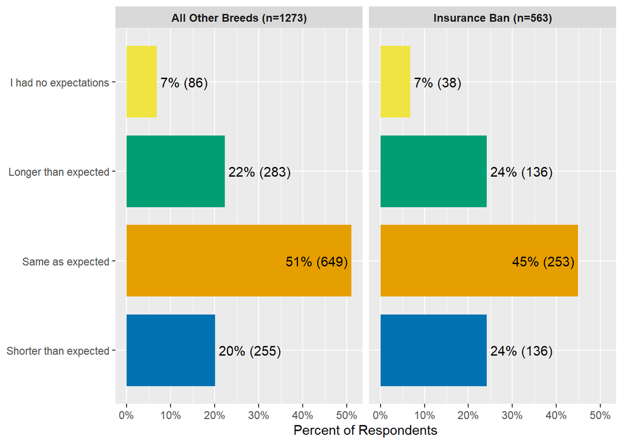

##### >>> Q22

**Why do you think it took as long as it did to get a puppy?**

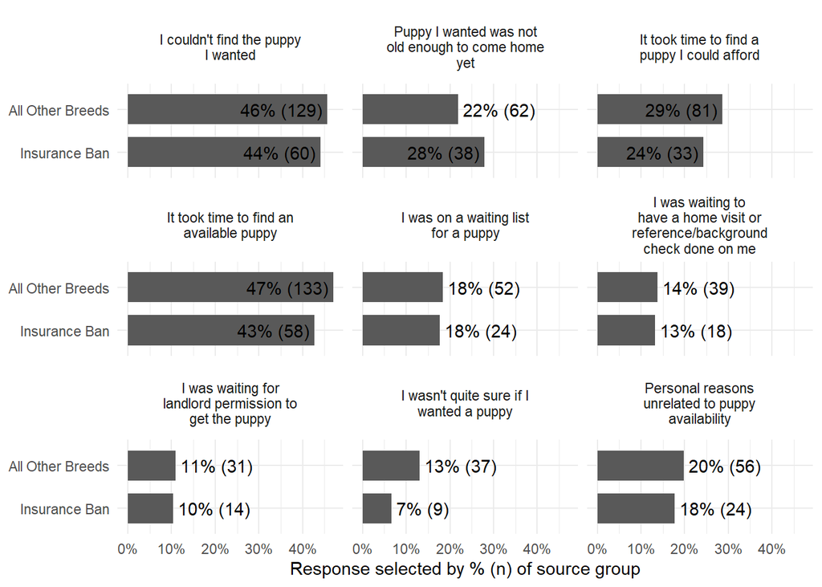

##### >>> Q23

**Why do you think you got your puppy faster than expected?**

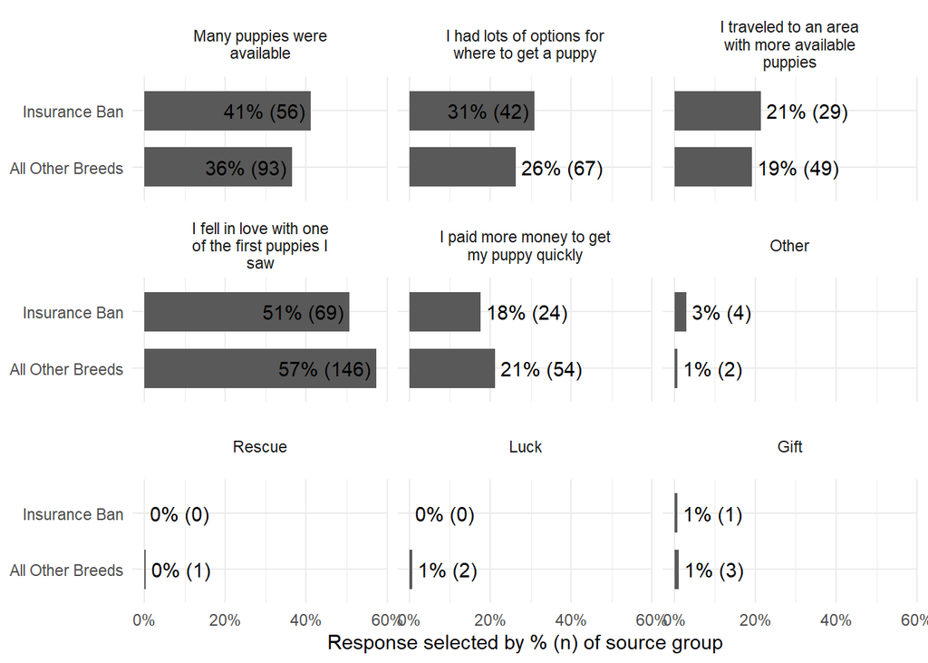

#### >> Motivation/Preferences for Puppy Features

#### >> Q24

**Q24: How closely did the puppy you got match what you were searching for?**

1896 non-empty/NA responses out of 1896 possible responses ( 100 %)

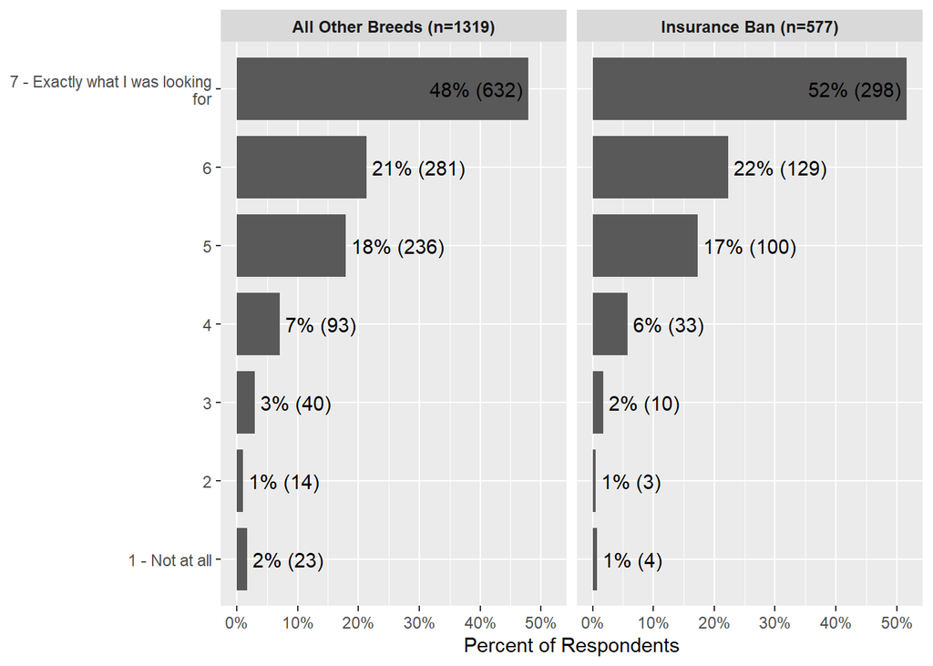

#### >> Q25 (…)

**How important were each of the following in choosing your puppy?**

1896 total non-empty/NA responses from 1896 possible respondents ( 100 %)

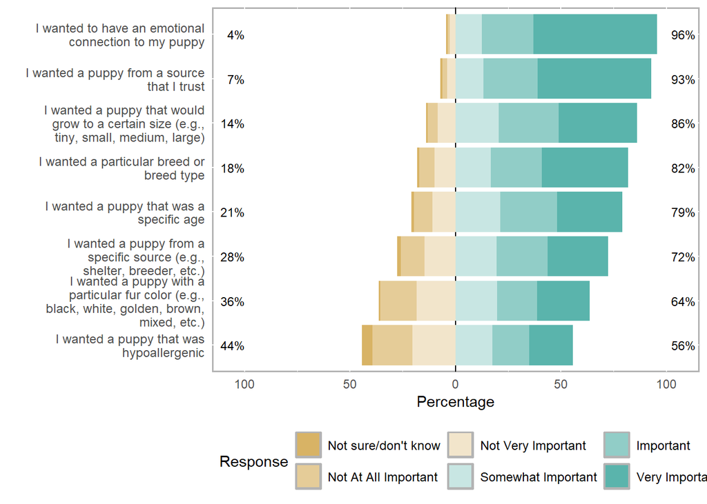

##### >>> Q25

**Q25r1: I wanted a puppy from a specific source (e.g., shelter, breeder, etc.) - How important were each of the following in choosing your puppy?**

1896 non-empty/NA responses out of 1896 possible responses ( 100 %)

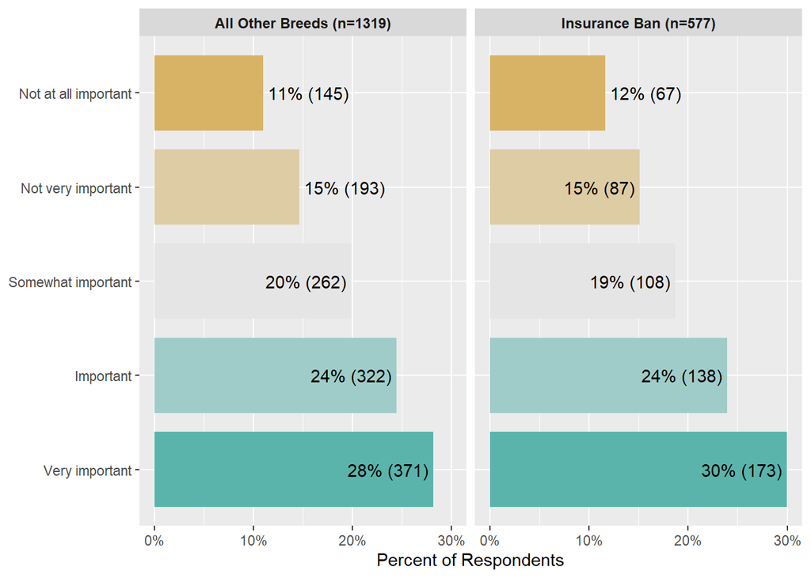

##### >>> Q25r2

**Q25r2: I wanted a puppy that was a specific age - How important were each of the following in choosing your puppy?**

1896 non-empty/NA responses out of 1896 possible responses ( 100 %)

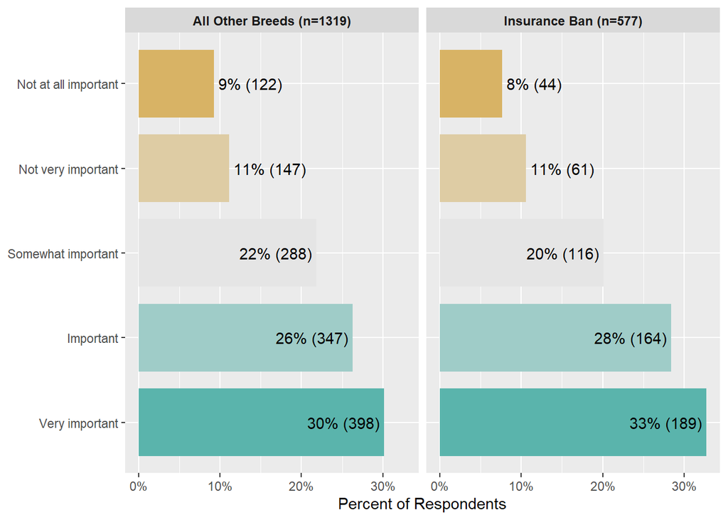

##### >>> Q25r3

**Q25r3: I wanted a puppy that would grow to a certain size (e.g., tiny, small, medium, large) - How important were each of the following in choosing your puppy?**

1896 non-empty/NA responses out of 1896 possible responses ( 100 %)

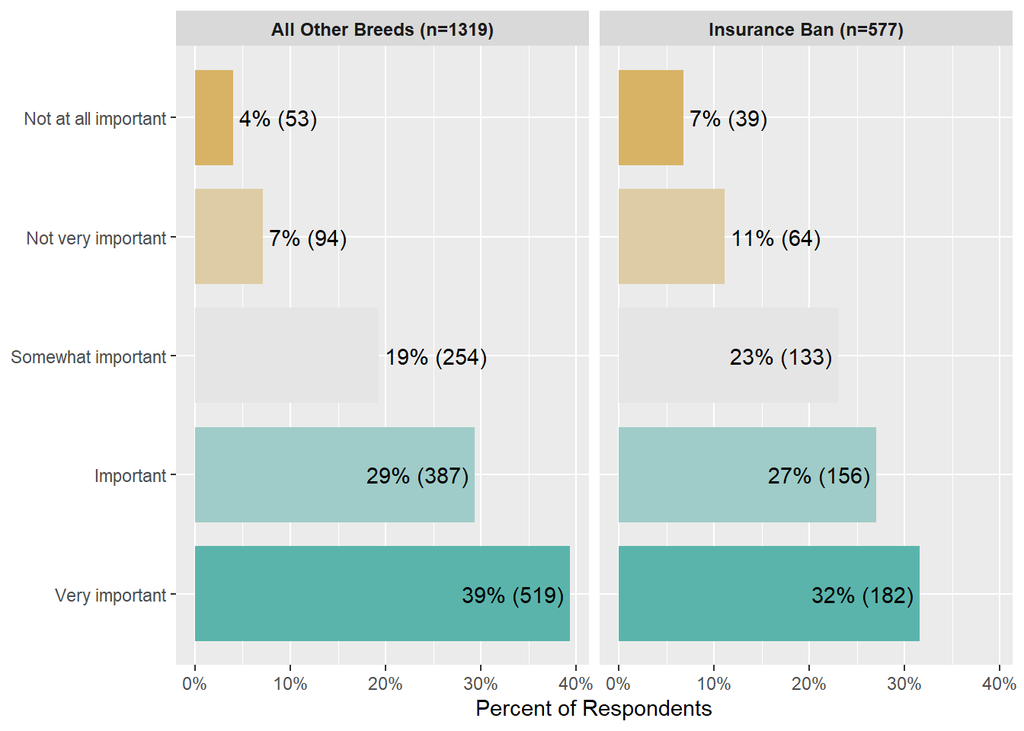

##### >>> Q25r4

**Q25r4: I wanted a particular breed or breed type - How important were each of the following in choosing your puppy?**

1896 non-empty/NA responses out of 1896 possible responses ( 100 %)

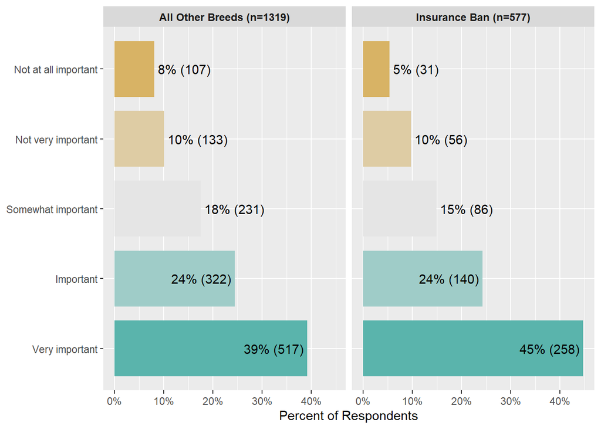

##### >>> Q25r5

**Q25r5: I wanted to have an emotional connection to my puppy - How important were each of the following in choosing your puppy?**

1896 non-empty/NA responses out of 1896 possible responses ( 100 %)

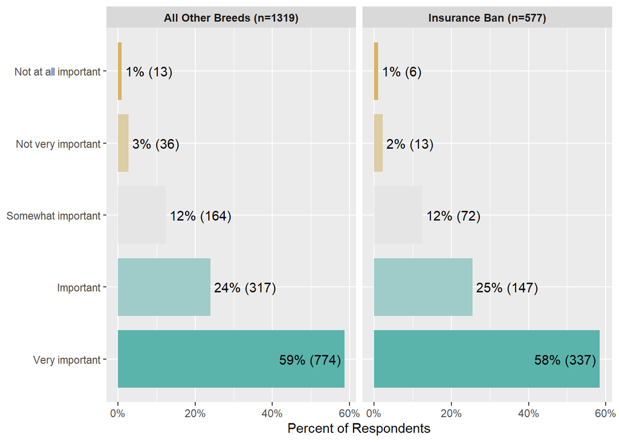